# Estudios de Informática, Multimedia y Telecomunicaciones

# Visualización de datos - PRA2 - Limpieza del dataset

Jose Luis Santos Durango

2023-01-21

# 1 Lectura del fichero de datos

Cargamos el archivo de datos y examinamos el tipo de datos con los que R ha interpretado cada variable. Examinaremos también los valores resumen de cada tipo de variable.

```r
# Cargamos el fichero de datos
df <- read.csv("AB_NYC_2019.csv", sep=",")
```

Veamos ahora el tipo de datos con los que R ha identificado cada una de las variables.

```r
str(df)
```

```
## 'data.frame':    48895 obs. of  16 variables:
##  $ id                            : int  2539 2595 3647 3831 5022 5099 5121 5178 5203 5238 ...
##  $ name                          : chr  "Clean & quiet apt home by the park" "Skylit Midtown Castle" "THE VILLAGE OF HARLEM....NEW YORK !" "Cozy Entire Floor of Brownstone" ...
##  $ host_id                       : int  2787 2845 4632 4869 7192 7322 7356 8967 7490 7549 ...
##  $ host_name                     : chr  "John" "Jennifer" "Elisabeth" "LisaRoxanne" ...
##  $ neighbourhood_group           : chr  "Brooklyn" "Manhattan" "Manhattan" "Brooklyn" ...
##  $ neighbourhood                 : chr  "Kensington" "Midtown" "Harlem" "Clinton Hill" ...
##  $ latitude                      : num  40.6 40.8 40.8 40.7 40.8 ...
##  $ longitude                     : num  -74 -74 -73.9 -74 -73.9 ...
##  $ room_type                     : chr  "Private room" "Entire home/apt" "Private room" "Entire home/apt" ...
##  $ price                         : int  149 225 150 89 80 200 60 79 79 150 ...
##  $ minimum_nights                : int  1 1 3 1 10 3 45 2 2 1 ...
##  $ number_of_reviews             : int  9 45 0 270 9 74 49 430 118 160 ...
##  $ last_review                   : chr  "2018-10-19" "2019-05-21" "" "2019-07-05" ...
##  $ reviews_per_month             : num  0.21 0.38 NA 4.64 0.1 0.59 0.4 3.47 0.99 1.33 ...
##  $ calculated_host_listings_count: int  6 2 1 1 1 1 1 1 1 4 ...
##  $ availability_365              : int  365 355 365 194 0 129 0 220 0 188 ...
```

Examinemos los valores resumen de cada una de las variables.

```r
summary(df)
```

```
##        id               name              host_id           host_name
##  Min.   :    2539   Length:48895       Min.   :     2438   Length:48895
##  1st Qu.: 9471945   Class :character   1st Qu.:  7822033   Class :character
##  Median :19677284   Mode  :character   Median : 30793816   Mode  :character
##  Mean   :19017143                      Mean   : 67620011
##  3rd Qu.:29152178                      3rd Qu.:107434423
##  Max.   :36487245                      Max.   :274321313
##
##  neighbourhood_group neighbourhood         latitude       longitude
##  Length:48895        Length:48895       Min.   :40.50   Min.   :-74.24
##  Class :character    Class :character   1st Qu.:40.69   1st Qu.:-73.98
##  Mode  :character    Mode  :character   Median :40.72   Median :-73.96
##                                         Mean   :40.73   Mean   :-73.95
##                                         3rd Qu.:40.76   3rd Qu.:-73.94
##                                         Max.   :40.91   Max.   :-73.71
##
##   room_type             price         minimum_nights    number_of_reviews
##  Length:48895       Min.   :    0.0   Min.   :   1.00   Min.   :  0.00
##  Class :character   1st Qu.:   69.0   1st Qu.:   1.00   1st Qu.:  1.00
##  Mode  :character   Median :  106.0   Median :   3.00   Median :  5.00
##                     Mean   :  152.7   Mean   :   7.03   Mean   : 23.27
##                     3rd Qu.:  175.0   3rd Qu.:   5.00   3rd Qu.: 24.00
##                     Max.   :10000.0   Max.   :1250.00   Max.   :629.00
##
##  last_review        reviews_per_month calculated_host_listings_count
##  Length:48895       Min.   : 0.010    Min.   :  1.000
##  Class :character   1st Qu.: 0.190    1st Qu.:  1.000
##  Mode  :character   Median : 0.720    Median :  1.000
##                     Mean   : 1.373    Mean   :  7.144
##                     3rd Qu.: 2.020    3rd Qu.:  2.000
##                     Max.   :58.500    Max.   :327.000
##                     NA's   :10052
##  availability_365
##  Min.   :  0.0
##  1st Qu.:  0.0
##  Median : 45.0
##  Mean   :112.8
##  3rd Qu.:227.0
##  Max.   :365.0
##
```

Podemos ver que el fichero de datos tiene un total de 48895 registros con 16 variables (features cada uno). De estas 16 variables, seleccionaremos solo aquellas en las que tenemos la información que nos interesará a la hora de analizar. Además será interesante estudiar si existe una correlación importante entre algunas de las variables.

# 2 Reducción de la dimensionalidad: elimación de columnas.

En este apartado vamos a estudiar la correlación posible existente entre las variables numéricas. Para ello tenemos que ver cuáles son las variables numéricas, y reemplazar los valores “NA” en aquellas donde existan estos valores. Una vez que tenemos esto, realizaremos un gráfico heatmap para ver si alguna correlación es alta.

```r
colSums(is.na(df))
```

```
##                             id                           name
##                              0                              0
##                        host_id                      host_name
##                              0                              0
##            neighbourhood_group                  neighbourhood
##                              0                              0
##                       latitude                      longitude
##                              0                              0
##                      room_type                          price
##                              0                              0
##                 minimum_nights              number_of_reviews
##                              0                              0
##                    last_review              reviews_per_month
##                              0                          10052
## calculated_host_listings_count               availability_365
##                              0                              0
```

Podemos ver que la única variables que contiene “NA”, es la variable reviews_per_month. Entendemos que este valor indica que existen cero reseñas por mes y por lo tanto vamos a cambiar el valor NA por cero.

```r
rows <- which(is.na(df$reviews_per_month))
df$reviews_per_month[rows] <- 0
colSums(is.na(df))
```

```
##                             id                           name
##                              0                              0
##                        host_id                      host_name
##                              0                              0
##            neighbourhood_group                  neighbourhood
##                              0                              0
##                       latitude                      longitude
##                              0                              0
##                      room_type                          price
##                              0                              0
##                 minimum_nights              number_of_reviews
##                              0                              0
##                    last_review              reviews_per_month
##                              0                              0
## calculated_host_listings_count               availability_365
##                              0                              0
```

Una vez tenemos los datos numéricos sin valores nulos, vamos a representar el heatmap.

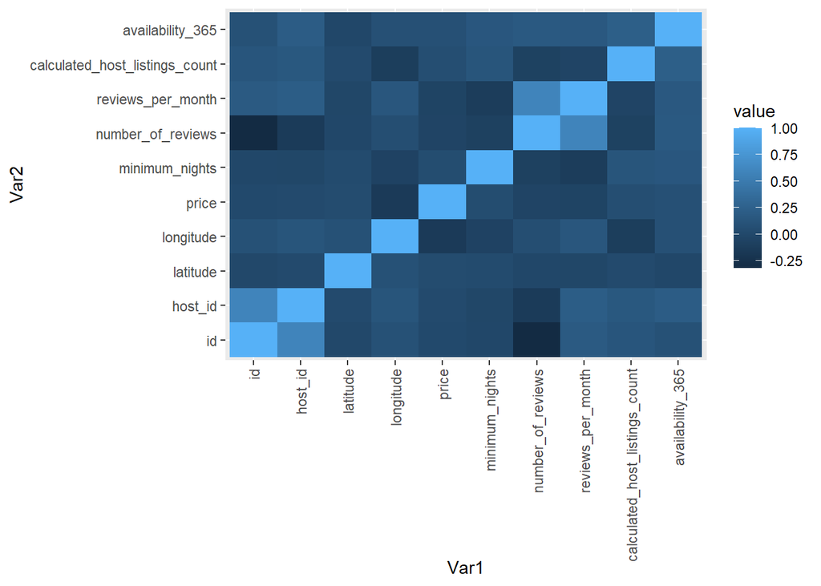

```r
if (!require('ggplot2')) install.packages('ggplot2'); library('ggplot2')
if (!require('reshape2')) install.packages('reshape2'); library('reshape2')
numeric_columns <- c("id",
                      "host_id",
                     "latitude",
                     "longitude",
                     "price",
                     "minimum_nights",
                     "number_of_reviews",
                     "reviews_per_month",
                     "calculated_host_listings_count",
                     "availability_365")

df_heatmap <- df[,numeric_columns]
data <- cor(df_heatmap[sapply(df_heatmap,is.numeric)])
data1 <- melt(data)

ggplot(data1, aes(x = Var1,
                  y = Var2,
                  fill = value))+geom_tile()+theme(axis.text.x = element_text(angle = 90, vjust = 0.5, hjust=1))
```

```r
cols_delete <- c("id",
                 "name",
                 "host_id",
                 "host_name",
                 "last_review",
                 "reviews_per_month",
                 "calculated_host_listings_count")
df<- df[, ! names(df) %in% cols_delete, drop = F]

# Cambiamos los nombres de neighbourhood_group
names(df)[names(df) == 'neighbourhood_group'] <- 'district'

# Comprobamos ahora la dimensión del nuevo dataset
str(df)
```

```
## 'data.frame':    48895 obs. of  9 variables:
##  $ district         : chr  "Brooklyn" "Manhattan" "Manhattan" "Brooklyn" ...
##  $ neighbourhood    : chr  "Kensington" "Midtown" "Harlem" "Clinton Hill" ...
##  $ latitude         : num  40.6 40.8 40.8 40.7 40.8 ...
##  $ longitude        : num  -74 -74 -73.9 -74 -73.9 ...
##  $ room_type        : chr  "Private room" "Entire home/apt" "Private room" "Entire home/apt" ...
##  $ price            : int  149 225 150 89 80 200 60 79 79 150 ...
##  $ minimum_nights   : int  1 1 3 1 10 3 45 2 2 1 ...
##  $ number_of_reviews: int  9 45 0 270 9 74 49 430 118 160 ...
##  $ availability_365 : int  365 355 365 194 0 129 0 220 0 188 ...
```

Luego las variables que usaremos en el proyectos son:

- **neighbourhood_group**: distrito.
- **neighbourhood**: barrio.
- **latitude**: latitud.
- **longitude**: longitud.
- **room_type**: tipo de habitación.
- **price**: precio por noche.
- **minimum nights**: mínimo número de noches por estancia.
- **number_of_reviews**: número de reseñas del alojamiento.
- **availability_365**: disponibilidad en días por año.

# 3 Reducción de la dimensionalidad: eliminación de registros

## 3.1 Distribución de los datos cualitativos.

En este apartado vamos a visualizar las distintas categorías de las variables cualitativas para ver si tenemos que realizar algún ajuste. Para ello vamos a visualizar la distribución que siguen las variables.

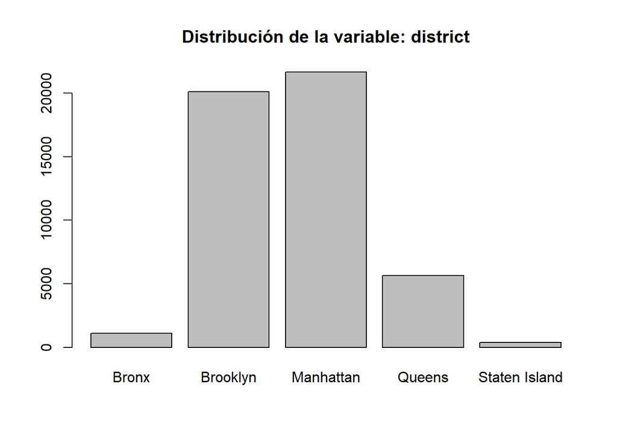

```r
# Ditribución de las variables cualitativas
barplot(table(df$district), main="Distribución de la variable: district")
```

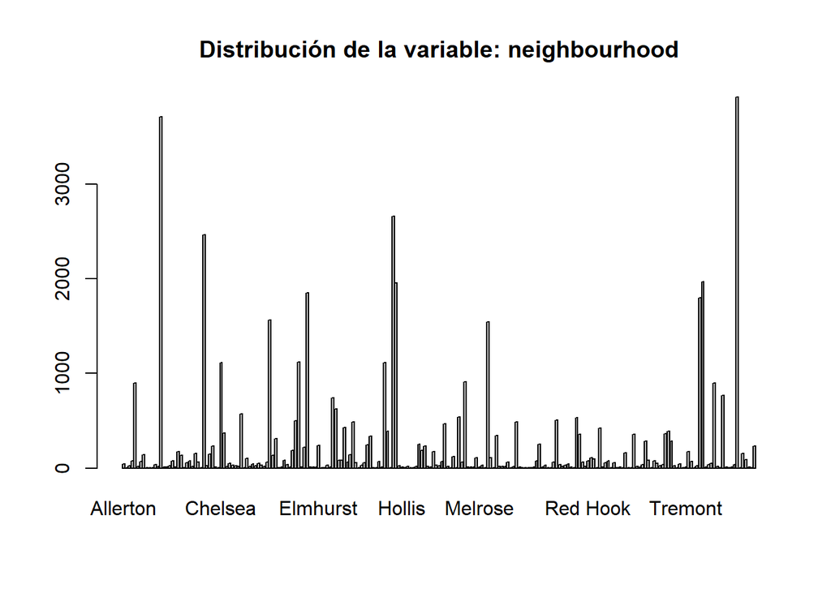

```r
barplot(table(df$neighbourhood), main="Distribución de la variable: neighbourhood")
```

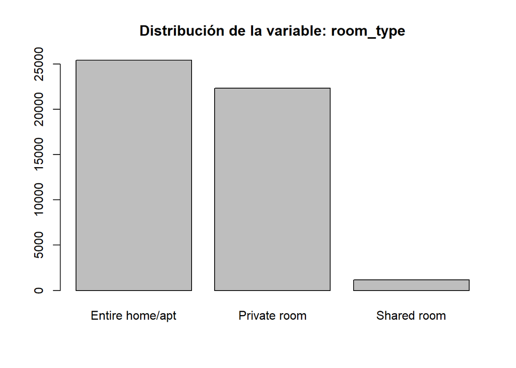

```r
barplot(table(df$room_type), main="Distribución de la variable: room_type")
```

## 3.2 Distribución de los datos cuantitativos.

Veamos ahora mediante histograma y diagramas de cajas la distribución de los datos cuantitativos.

### 3.2.1 Ditribución de la variable: price

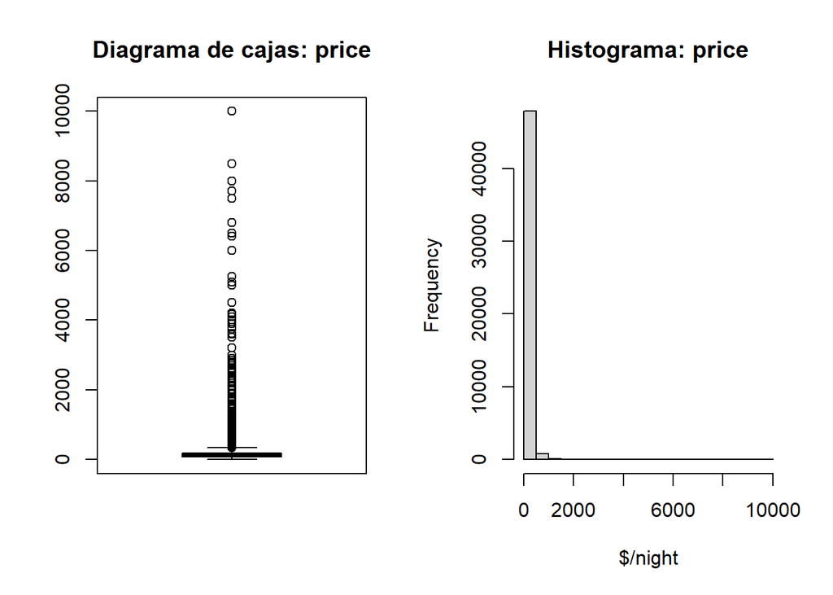

```r
par(mfrow=c(1,2))
boxplot(df$price, main="Diagrama de cajas: price")
hist(df$price, main="Histograma: price",xlab="$/night")
```

Podemos observar que la mayoría de alojamientos se concentran en precios hasta los 500 dólares/noche. El resto de alojamientos son escasos y hay algunos superan los 5000 dólares/noche, pero casos muy específicos.

### 3.2.2 Ditribución de la variable: minimum_nights, availability_365

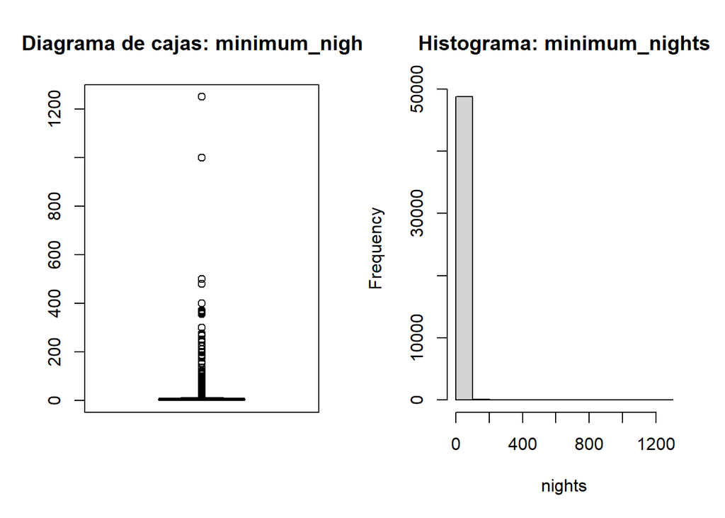

```r
par(mfrow=c(1,2))
boxplot(df$minimum_nights, main="Diagrama de cajas: minimum_nights")
hist(df$minimum_nights, main="Histograma: minimum_nights",xlab="nights")
```

Podemos observar que hay algunos alojamientos donde el minimum_nights supera los 365 que es lo máximo que se puede alquilar en un año (si es bisiesto serían 366)

```r
df<-df[df$minimum_nights <= 366, ]
dim(df)
```

```
## [1] 48882     9
```

Veamos si ocurre algo parecido con la variable que indica la disponibilidad anual de los alojamientos.

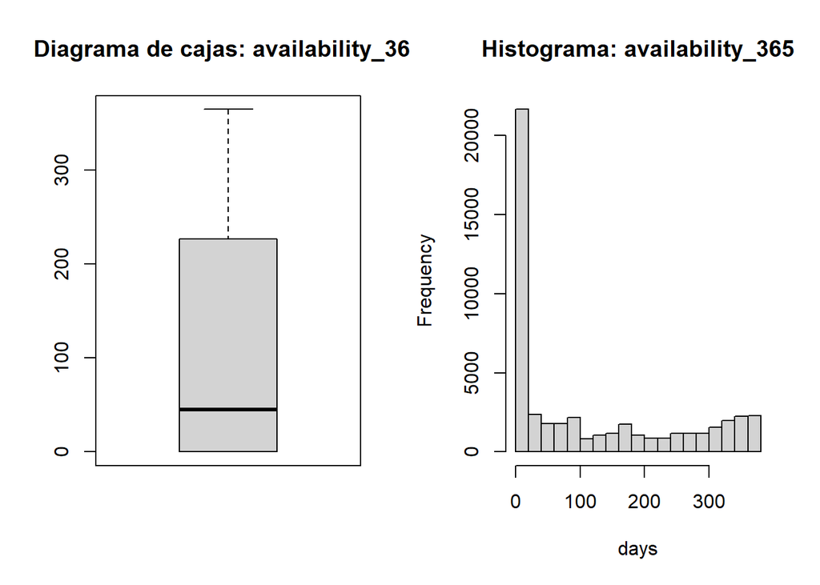

```r
par(mfrow=c(1,2))
boxplot(df$availability_365, main="Diagrama de cajas: availability_365")
hist(df$availability_365, main="Histograma: availability_365",xlab="days")
```

En este caso no parece haber ningún registro donde la disponibilidad supere el número de días en un año, por lo que no se realiza ninguna transformación.